# Duplicate Document Detection with Python

If you ever worked with text documents, there is a high probability that you’ve had to deal with duplicate content at some point or the other. The process of manually scanning every document to detect duplicates is a tedious and, often, ineffective one.

This presentation focuses on designing a machine learning model that not only identifies similar documents based on their text similarity, but also utilizes the documents’ metadata to confirm that a pair of similar documents are indeed duplicates, thus reducing the need for any manual intervention in detecting duplicate documents. The solution is a **2-step** process which involves calculating the text similarity between two documents, and subjecting the pair to a classifier for a verdict.

A sneak-peek into the solution:

**Text Similarity - Candidate Duplicates** When a new document enters the workflow, a cosine similarity score is calculated between the new document and every other document in the corpus. Document pairs that have similarity scores greater than a set threshold are filtered as ‘Candidate Duplicates’. This filtering means that we are ready to accept that all the pairs that have similarity scores lesser than our set similarity threshold are not duplicates.

**Classifier** These candidate duplicates will now be subjected to a trained classifier which will classify pairs of documents as duplicates based on their metadata features. Our classifier is a decision tree classification model that is trained on labeled duplicate documents and labeled non-duplicate documents, along with their corresponding similarity scores and metadata features like the document lengths, filing dates, document types etc.

The main reason behind using a classifier layer on top of cosine similarity scores is the way in which some press release documents/ mandatory disclosures/ news articles etc are filed. Documents which need to be filed every month/quarter under a specific format with minor changes in data, cannot be considered as duplicates, although they might have high text similarity. We call such documents - *High Similarity Non Duplicates*.  
Through our 2-step process, let us see how we can identify such high similarity non duplicates along with duplicate documents.

### Glossary of Terms:

**Document**: A news article.  
**Corpus**: A collection of documents (news articles).  
**TFIDF Score**: A statistic that determines how important a word is to a particular document when compared against several documents in the corpus.  
**Corpus TFIDF Matrix**: A matrix of TFIDF scores for every document against every word in the corpus.  
**TFIDF Model**: A TFIDF model trained on all the words from the corpus - which can be used later to calculate TFIDF scores for test documents against all the words from the corpus.  
**Test TFIDF Matrix**: A matrix of TFIDF scores calculated for test documents against all the words from the corpus using the TFIDF (trained) model.  
**Cosine Similarity / Similarity Score**: A score that measures similarity between two vectors (TFIDF vectors in this case) by taking the cosine of the angle between those vectors. Cosine similarity between the Corpus TFIDF Matrix and the Test TFIDF Matrix means that the similarity scores are calculated between the every document (vector) from the test documents and every document (vector) of the corpus.  
**Similarity Threshold**: A cut off on similarity score which is calculated as the 5th percentile of the similarity score from labeled duplicate pairs of documents.  
**Candidate Duplicates**: Pairs of documents that have similarity scores greater than the similarity threshold. These pairs are subjected to the classifier to determine definite duplicates.  
**Classifier**: A decision tree classification model that is trained on labeled duplicate document pairs and labeled non-duplicate document pairs along with other metadata features.  
**High Similarity Non-duplicates**: Pairs of documents that have high similarity scores (similar enough to be duplicates) but are not considered duplicates because they have been filed too far apart (different quarters).

# Get data

```python
# Get data into a variable
data = datasets.fetch_20newsgroups()
data.keys()
```

```
dict_keys(['data', 'filenames', 'target_names', 'target', 'DESCR', 'description'])
```

The dataset has 11314 news articles across 20 news groups. It has the above mentioned attributes - data, filenames, target names (the group that each file belongs to) and labels, and overall dataset description.

### Extract IDs from filepaths

```python
# Get filepaths into a variable to extract file names
filepaths = data.filenames.astype(str)
filepaths
```

```
array([ '/Users/manasa.bulusu/scikit_learn_data/20news_home/20news-bydate-train/rec.autos/102994',
       '/Users/manasa.bulusu/scikit_learn_data/20news_home/20news-bydate-train/comp.sys.mac.hardware/51861',
       '/Users/manasa.bulusu/scikit_learn_data/20news_home/20news-bydate-train/comp.sys.mac.hardware/51879',
       ...,
       '/Users/manasa.bulusu/scikit_learn_data/20news_home/20news-bydate-train/comp.sys.ibm.pc.hardware/60695',
       '/Users/manasa.bulusu/scikit_learn_data/20news_home/20news-bydate-train/comp.graphics/38319',
       '/Users/manasa.bulusu/scikit_learn_data/20news_home/20news-bydate-train/rec.motorcycles/104440'],
      dtype='<U101')
```

The filenames attribute has the full path of the file, instead of the file name. This can make our dataset look untidy. I am using the `split` function from `os.path` to split the name of the text file from its path.

```python
# Keys variable for filenames
keys = []
for path in filepaths:
    keys.append(os.path.split(path)[1])

keys[0:5]
```

```
['102994', '51861', '51879', '38242', '60880']
```

Now, we can see just the names of the files which will act as unique identifiers for this dataset.

### Create metadata

We need metadata to train the classifier (step 2 of the solution). Let's create a dataframe and gather all the metadata into it.

```python
# Create a dataframe with metadata columns
metadata = pd.DataFrame(keys, columns = ['Document_ID'] )
metadata['Group'] = data.target
metadata['Text'] = data.data
```

```python
# Get stats on dataset
print ("Rows:",len(metadata))
print ("Distinct IDs:",len(metadata['Document_ID'].drop_duplicates()))
print ("Distrinct Groups:",len(metadata['Group'].drop_duplicates()))
```

```
Rows: 11314
Distinct IDs: 9840
Distrinct Groups: 20
```

We can observe that there are 9840 distinct filenames that have been repeated over 11314 rows. We don't want two different files to have the same filename.

```python
# Example of filename repetition
metadata.loc[[5392,5680]]
```

|  | Document_ID | Group | Text |
| --- | --- | --- | --- |
| 5392 | 76139 | 6 | From: jllee@acsu.buffalo.edu (Johnny L Lee)\nS... |
| 5680 | 76139 | 17 | From: hovig@uxa.cso.uiuc.edu (Hovig Heghinian)... |

Here, we notice that some of the filenames (IDs) have been repeated across groups. So, let us make the filenames more unique, so there's just one such ID for the whole dataset.

```python
# One group for each ID
# Some of the IDs have been re-used within different groups. Making sure that no ID is repeated.
metadata['Document_ID'] = metadata['Document_ID'].astype(int)
dupes = metadata.Document_ID.duplicated(keep='first')
max_id = metadata.Document_ID.max() + 1
new_id = range(max_id, max_id + dupes.sum())
metadata.loc[dupes, 'Document_ID'] = new_id

print ("Rows:",len(metadata))
print ("Distinct IDs:",len(metadata['Document_ID'].drop_duplicates()))
print ("Distrinct Groups:",len(metadata['Group'].drop_duplicates()))

# Test
metadata.loc[[5392,5680]]
```

```
Rows: 11314
Distinct IDs: 11314
Distrinct Groups: 20
```

|  | Document_ID | Group | Text |
| --- | --- | --- | --- |
| 5392 | 76139 | 6 | From: jllee@acsu.buffalo.edu (Johnny L Lee)\nS... |
| 5680 | 179489 | 17 | From: hovig@uxa.cso.uiuc.edu (Hovig Heghinian)... |

#### Calculate length as derived variable

Using the text column in the dataset, we calculate the length of each document.

```python
# Add a derived column for lengths of texts
lengths = []
for i in metadata['Text']:
    lengths.append(len(i))

metadata['Length'] = lengths
metadata.head()
```

|  | Document_ID | Group | Text | Length |
| --- | --- | --- | --- | --- |
| 0 | 102994 | 7 | From: lerxst@wam.umd.edu (where's my thing)\nS... | 721 |
| 1 | 51861 | 4 | From: guykuo@carson.u.washington.edu (Guy Kuo)... | 858 |
| 2 | 51879 | 4 | From: twillis@ec.ecn.purdue.edu (Thomas E Will... | 1981 |
| 3 | 38242 | 1 | From: jgreen@amber (Joe Green)\nSubject: Re: W... | 815 |
| 4 | 60880 | 14 | From: jcm@head-cfa.harvard.edu (Jonathan McDow... | 1120 |

#### Add dates

Since dates are an important feature in determining **high similarity non-duplicates**, let us assign some dates to our news articles.

```python
# Assign dates to news articles
np.random.seed(123)
date_list = pd.date_range(datetime.date(datetime.now()) - timedelta(180), datetime.date(datetime.now()), freq='D')
dates = []
for i in metadata['Document_ID']:
    dates.append(np.random.choice(date_list, replace = True))

metadata['Date'] = dates
metadata.head()
```

|  | Document_ID | Group | Text | Length | Date |
| --- | --- | --- | --- | --- | --- |
| 0 | 102994 | 7 | From: lerxst@wam.umd.edu (where's my thing)\nS... | 721 | 2017-11-02 |
| 1 | 51861 | 4 | From: guykuo@carson.u.washington.edu (Guy Kuo)... | 858 | 2017-11-19 |
| 2 | 51879 | 4 | From: twillis@ec.ecn.purdue.edu (Thomas E Will... | 1981 | 2017-09-20 |
| 3 | 38242 | 1 | From: jgreen@amber (Joe Green)\nSubject: Re: W... | 815 | 2017-10-22 |
| 4 | 60880 | 14 | From: jcm@head-cfa.harvard.edu (Jonathan McDow... | 1120 | 2017-08-02 |

```python
# Final Metadata
metadata = metadata[['Document_ID', 'Group', 'Length', 'Date']]
metadata.head()
```

|  | Document_ID | Group | Length | Date |
| --- | --- | --- | --- | --- |
| 0 | 102994 | 7 | 721 | 2017-11-02 |
| 1 | 51861 | 4 | 858 | 2017-11-19 |
| 2 | 51879 | 4 | 1981 | 2017-09-20 |
| 3 | 38242 | 1 | 815 | 2017-10-22 |
| 4 | 60880 | 14 | 1120 | 2017-08-02 |

This is how the metadata dataframe looks - with features: ID, Group, Length and Date.

Once we have the metadata ready, let us proceed to the next step. Our first step towards detecting duplicate documents is calculating text similarity scores.

# Get Text Similarity

But first, let us split our 11314 news articles into a base corpus (against which duplicate detection is carried out) and a test set (which is tested for duplicate articles).

Consider `corpus` as a collection of news articles you already have, and `test set` as a new set of news articles that you want to add to your repository. We will now find out, if there are already duplicate articles in your corpus collection that match the 314 test cases.

This process can also be carried with all the 11314 news articles at once - to see if there are any duplicate articles in the corpus itself. But, that is for another demo.

```python
# Split data into existing corpus and test articles
corpus = data.data[0:11000]
corpus_keys = keys[0:11000]
print (len(corpus_keys))

test = data.data[11000:11314]
test_keys = keys[11000:11314]
print (len(test_keys))
```

```
11000
314
```

### Build TFIDF Matrices

Before calculating text similarity scores, we need to build TFIDF Matrices.  
**TFIDF Score**: `Term Frequency - Inverse Document Frequency` is a statistic that determines how important a word is to a particular document when compared against several documents in the corpus.  
**TFIDF Matrix**: A matrix of TFIDF scores for every document against every word in the corpus.

```python
# Use scikit-learn tfidf vectorizer to build a TFIDF Matrix for the corpus
tfidf = TfidfVectorizer()
corpus_tfidf_matrix = tfidf.fit_transform(corpus)
corpus_tfidf_matrix.shape
```

```
(11000, 128684)
```

We use the same TFIDF model to get the TFIDF matrix for the test set as well.  
**TFIDF Model**: A TFIDF model trained on all the words from the corpus - which can be used later to calculate TFIDF scores for test documents against all the words from the corpus.

```python
# Use scikit-learn tfidf vectorizer to build a TFIDF matrix for test articles.
test_tfidf_matrix = tfidf.transform(test)
test_tfidf_matrix.shape
```

```
(314, 128684)
```

### Calculate similarity scores

Here, I'm using a custom built function that uses scikit-learn's `cosine_similarity` function to calculate cosine similarities and returns the scores along with ID-pairs in a dataframe.

```python
# Calculate similarity scores using our trained TFIDF Matrix and test keys.
similarity_scores = similarity(corpus_keys, corpus_tfidf_matrix, test_keys, test_tfidf_matrix).rename(columns = {'KF1':'ID1', 'KF2':'ID2'})
similarity_scores = similarity_scores.sort_values('Similarity_Score',ascending = False)
similarity_scores[['ID1', 'ID2']] = similarity_scores[['ID1', 'ID2']].astype(int)
display(similarity_scores.head())

print ("Number of combination of similarity scores:", len(similarity_scores))
```

|  | ID1 | ID2 | Similarity_Score |
| --- | --- | --- | --- |
| 3312853 | 83490 | 83482 | 0.998640 |
| 770581 | 66999 | 67120 | 0.993592 |
| 3345232 | 84175 | 84011 | 0.984961 |
| 918708 | 58965 | 58913 | 0.967122 |
| 450076 | 66431 | 66451 | 0.966800 |

```
Number of combination of similarity scores: 3454000
```

The above similarity scores mark the end of step 1 for detecting duplicates. In a case when you wouldn't want to worry about document metadata or high similarity non duplicates, this is where you can stop. Consider pairs of documents that have cosine similarity scores of `x` or above as duplicates.  
However, if you care about the document metadata, consider pairs of documents that have cosine similarity scores of `y` or above as candidate duplicates, and proceed to the next step.

# Filter Candidate Duplicates

Instead of subjecting all pairs of articles to the classifier, we filter a set of candidate duplicates using a similarity threshold. Similarity threshold is calculated as the 5% th percentile from the similarity scores of labeled duplicate articles. This means that only 5% of all labeled duplicate articles have similarity scores below the similarity threshold.

By filtering candidate duplicates from a wider set of articles, we are reducing the burden on the classifier. Here, the number of combinations of articles has reduce from 3454000 to 22 after filtering for candidate duplicates. Setting such a threshold means that we are ready to lose 5% of duplicate articles without detecting them.

```python
# Filter data by similarity threshold to get candidate duplicates
similarity_threshold = 0.87 # as calculated from labeled duplicate similarities - 5% loss in detection.
candidate_duplicates = similarity_scores[similarity_scores['Similarity_Score']>similarity_threshold]
print ("Number of candidate duplicates:", len(candidate_duplicates))
```

```
Number of candidate duplicates: 22
```

### Get metadata for candidate duplicates

Once we have those candidate duplicates, we merge the metadata of these pairs of articles to pass them into the classifier.

```python
# Merge metadata features with candidate duplicates
candidate_duplicates = candidate_duplicates.merge(metadata, how = 'inner', left_on = 'ID1', right_on = 'Document_ID').rename(columns = {'Document_ID':'Document_ID1', 'Group':'Group_ID1', 'Length':'Length_ID1', 'Date':'Date_ID1'})
candidate_duplicates = candidate_duplicates.merge(metadata, how = 'inner', left_on = 'ID2', right_on = 'Document_ID').rename(columns = {'Document_ID':'Document_ID2', 'Group':'Group_ID2', 'Length':'Length_ID2', 'Date':'Date_ID2'})
candidate_duplicates
```

|  | ID1 | ID2 | Similarity_Score | Document_ID1 | Group_ID1 | Length_ID1 | Date_ID1 | Document_ID2 | Group_ID2 | Length_ID2 | Date_ID2 |
| --- | --- | --- | --- | --- | --- | --- | --- | --- | --- | --- | --- |
| 0 | 83490 | 83482 | 0.998640 | 83490 | 19 | 8258 | 2017-12-31 | 83482 | 19 | 8264 | 2017-07-26 |
| 1 | 66999 | 67120 | 0.993592 | 66999 | 5 | 350 | 2017-10-19 | 67120 | 5 | 369 | 2017-11-14 |
| 2 | 84175 | 84011 | 0.984961 | 84175 | 19 | 1657 | 2017-09-12 | 84011 | 19 | 1678 | 2017-08-07 |
| 3 | 58965 | 58913 | 0.967122 | 58965 | 13 | 5031 | 2017-11-07 | 58913 | 3 | 1148 | 2017-08-04 |
| 4 | 66431 | 66451 | 0.966800 | 66431 | 5 | 701 | 2017-12-24 | 66451 | 5 | 663 | 2017-07-16 |
| 5 | 76014 | 75949 | 0.963726 | 76014 | 6 | 1829 | 2017-08-10 | 75949 | 6 | 1767 | 2017-10-07 |
| 6 | 102751 | 102856 | 0.946843 | 102751 | 7 | 2630 | 2017-11-28 | 102856 | 7 | 2972 | 2017-08-25 |
| 7 | 178544 | 178892 | 0.936134 | 178544 | 18 | 1556 | 2017-09-08 | 178892 | 18 | 1838 | 2017-11-17 |
| 8 | 103055 | 103003 | 0.932118 | 103055 | 7 | 2126 | 2017-11-12 | 103003 | 7 | 1569 | 2017-10-20 |
| 9 | 102998 | 103003 | 0.910638 | 102998 | 7 | 1367 | 2017-10-04 | 103003 | 7 | 1569 | 2017-10-20 |
| 10 | 103038 | 103003 | 0.874358 | 103038 | 7 | 2181 | 2018-01-12 | 103003 | 7 | 1569 | 2017-10-20 |
| 11 | 75892 | 75952 | 0.927656 | 75892 | 6 | 3599 | 2017-09-27 | 75952 | 6 | 1262 | 2017-09-18 |
| 12 | 101613 | 101551 | 0.925883 | 101613 | 7 | 3694 | 2017-09-24 | 101551 | 7 | 2646 | 2017-08-28 |
| 13 | 60787 | 54233 | 0.916452 | 60787 | 14 | 693 | 2017-10-17 | 54233 | 16 | 708 | 2018-01-08 |
| 14 | 76413 | 76144 | 0.898538 | 76413 | 17 | 3891 | 2017-07-18 | 76144 | 6 | 555 | 2018-01-12 |
| 15 | 76048 | 76308 | 0.895531 | 76048 | 17 | 3672 | 2017-07-31 | 76308 | 17 | 5008 | 2017-07-20 |
| 16 | 83818 | 83670 | 0.894501 | 83818 | 19 | 1737 | 2017-11-05 | 83670 | 19 | 1386 | 2017-11-21 |
| 17 | 50422 | 58829 | 0.892086 | 50422 | 4 | 1020 | 2017-11-13 | 58829 | 13 | 2408 | 2017-12-13 |
| 18 | 102988 | 103756 | 0.889589 | 102988 | 7 | 1906 | 2017-09-06 | 103756 | 7 | 1749 | 2017-09-11 |
| 19 | 102641 | 102644 | 0.887938 | 102641 | 9 | 568 | 2017-10-07 | 102644 | 9 | 626 | 2017-12-22 |
| 20 | 76283 | 76340 | 0.879576 | 76283 | 17 | 1061 | 2017-11-20 | 76340 | 17 | 1171 | 2017-10-02 |
| 21 | 178952 | 178975 | 0.871628 | 178952 | 18 | 594 | 2017-08-02 | 178975 | 18 | 976 | 2017-07-28 |

Once we have the metadata, we calculate some derived variables from the metadata variables.

```python
# Feature-Engineering: Calculate derived variables
candidate_duplicates['Same_Group'] = np.where(candidate_duplicates['Group_ID1']==candidate_duplicates['Group_ID2'],1,0)
candidate_duplicates['Length_Difference'] = abs(candidate_duplicates['Length_ID1']-candidate_duplicates['Length_ID2'])
candidate_duplicates['Date_Difference'] = (abs(candidate_duplicates['Date_ID1']-candidate_duplicates['Date_ID2']))/ np.timedelta64(1, 'D')
```

Clean up the dataframe and keep only useful variables. I am also moving the unique identifiers into the index, so they don't disturb our prediction, and we have them for reference.

```python
# Keep only useful variables
candidate_duplicates = candidate_duplicates[['ID1', 'ID2', 'Similarity_Score', 'Length_ID1', 'Length_ID2', 'Group_ID1', 'Group_ID2' ,'Same_Group', 'Length_Difference', 'Date_Difference']]
candidate_duplicates = candidate_duplicates.set_index(['ID1', 'ID2'], drop = True)
candidate_duplicates
```

| ID1 | ID2 | Similarity_Score | Length_ID1 | Length_ID2 | Group_ID1 | Group_ID2 | Same_Group | Length_Difference | Date_Difference |
| --- | --- | --- | --- | --- | --- | --- | --- | --- | --- |
| 83490 | 83482 | 0.998640 | 8258 | 8264 | 19 | 19 | 1 | 6 | 158.0 |
| 66999 | 67120 | 0.993592 | 350 | 369 | 5 | 5 | 1 | 19 | 26.0 |
| 84175 | 84011 | 0.984961 | 1657 | 1678 | 19 | 19 | 1 | 21 | 36.0 |
| 58965 | 58913 | 0.967122 | 5031 | 1148 | 13 | 3 | 0 | 3883 | 95.0 |
| 66431 | 66451 | 0.966800 | 701 | 663 | 5 | 5 | 1 | 38 | 161.0 |
| 76014 | 75949 | 0.963726 | 1829 | 1767 | 6 | 6 | 1 | 62 | 58.0 |
| 102751 | 102856 | 0.946843 | 2630 | 2972 | 7 | 7 | 1 | 342 | 95.0 |
| 178544 | 178892 | 0.936134 | 1556 | 1838 | 18 | 18 | 1 | 282 | 70.0 |
| 103055 | 103003 | 0.932118 | 2126 | 1569 | 7 | 7 | 1 | 557 | 23.0 |
| 102998 | 103003 | 0.910638 | 1367 | 1569 | 7 | 7 | 1 | 202 | 16.0 |
| 103038 | 103003 | 0.874358 | 2181 | 1569 | 7 | 7 | 1 | 612 | 84.0 |
| 75892 | 75952 | 0.927656 | 3599 | 1262 | 6 | 6 | 1 | 2337 | 9.0 |
| 101613 | 101551 | 0.925883 | 3694 | 2646 | 7 | 7 | 1 | 1048 | 27.0 |
| 60787 | 54233 | 0.916452 | 693 | 708 | 14 | 16 | 0 | 15 | 83.0 |
| 76413 | 76144 | 0.898538 | 3891 | 555 | 17 | 6 | 0 | 3336 | 178.0 |
| 76048 | 76308 | 0.895531 | 3672 | 5008 | 17 | 17 | 1 | 1336 | 11.0 |
| 83818 | 83670 | 0.894501 | 1737 | 1386 | 19 | 19 | 1 | 351 | 16.0 |
| 50422 | 58829 | 0.892086 | 1020 | 2408 | 4 | 13 | 0 | 1388 | 30.0 |
| 102988 | 103756 | 0.889589 | 1906 | 1749 | 7 | 7 | 1 | 157 | 5.0 |
| 102641 | 102644 | 0.887938 | 568 | 626 | 9 | 9 | 1 | 58 | 76.0 |
| 76283 | 76340 | 0.879576 | 1061 | 1171 | 17 | 17 | 1 | 110 | 49.0 |
| 178952 | 178975 | 0.871628 | 594 | 976 | 18 | 18 | 1 | 382 | 5.0 |

### Make data ready for classification

Data Transformation process - remove duplicates, remove outliers, create dummy columns for categorical variables. Since our dataset has no missing values, we need not impute here.

```python
# Remove duplicate rows in the dataset
candidate_duplicates = candidate_duplicates.drop_duplicates()

# Remove outliers in the dataset
candidate_duplicates = candidate_duplicates.clip()
```

Convert categorical columns into one-hot encoded levels. Group IDs are the categorical variables in our dataset. Normally one would convert string group names to labels, but our dataset already has labels in it.

```python
# Load trained and saved one hot encoder
with open ("onehot.pkl", 'rb') as e:
        enc = pickle.load(e)

# Specify the column of data for the encoder to transform, using reshape. Repeat for KF1 and KF2
encoded_data_ID1 = enc.transform(candidate_duplicates['Group_ID1'].values.reshape(-1, 1))
encoded_data_ID2 = enc.transform(candidate_duplicates['Group_ID2'].values.reshape(-1, 1))

# Get column names for KF1_* and KF2_* for dataframe
ID1_columns = ['{}_{}'.format('ID1', i) for i in data.target_names]
ID2_columns = ['{}_{}'.format('ID2', i) for i in data.target_names]

# Index and rename columns of encoded dataset
encoded_data_ID1 = pd.DataFrame(encoded_data_ID1, index=candidate_duplicates.index, columns = ID1_columns)
encoded_data_ID2 = pd.DataFrame(encoded_data_ID2, index=candidate_duplicates.index, columns = ID2_columns)

# Concat KF1 and KF2 encoded data
encoded_data = pd.concat([encoded_data_ID1,encoded_data_ID2], axis = 1)

# Concat encoded columns with test data
candidate_duplicates = pd.concat([candidate_duplicates, encoded_data], axis=1)

# View encoded dataset
candidate_duplicates
```

| ID1 | ID2 | Similarity_Score | Length_ID1 | Length_ID2 | Group_ID1 | Group_ID2 | Same_Group | Length_Difference | Date_Difference | ID1_alt.atheism | ID1_comp.graphics | ... | ID2_rec.sport.hockey | ID2_sci.crypt | ID2_sci.electronics | ID2_sci.med | ID2_sci.space | ID2_soc.religion.christian | ID2_talk.politics.guns | ID2_talk.politics.mideast | ID2_talk.politics.misc | ID2_talk.religion.misc |
| --- | --- | --- | --- | --- | --- | --- | --- | --- | --- | --- | --- | --- | --- | --- | --- | --- | --- | --- | --- | --- | --- | --- |
| 83490 | 83482 | 0.998640 | 8258.0 | 8264.0 | 19.0 | 19.0 | 1.0 | 6.0 | 158.0 | 0 | 0 | ... | 0 | 0 | 0 | 0 | 0 | 0 | 0 | 0 | 1 | 0 |
| 66999 | 67120 | 0.993592 | 350.0 | 369.0 | 5.0 | 5.0 | 1.0 | 19.0 | 26.0 | 0 | 0 | ... | 0 | 0 | 0 | 0 | 0 | 0 | 0 | 0 | 0 | 0 |
| 84175 | 84011 | 0.984961 | 1657.0 | 1678.0 | 19.0 | 19.0 | 1.0 | 21.0 | 36.0 | 0 | 0 | ... | 0 | 0 | 0 | 0 | 0 | 0 | 0 | 0 | 1 | 0 |
| 58965 | 58913 | 0.967122 | 5031.0 | 1148.0 | 13.0 | 3.0 | 0.0 | 3883.0 | 95.0 | 0 | 0 | ... | 0 | 0 | 0 | 0 | 0 | 0 | 0 | 0 | 0 | 0 |
| 66431 | 66451 | 0.966800 | 701.0 | 663.0 | 5.0 | 5.0 | 1.0 | 38.0 | 161.0 | 0 | 0 | ... | 0 | 0 | 0 | 0 | 0 | 0 | 0 | 0 | 0 | 0 |
| 76014 | 75949 | 0.963726 | 1829.0 | 1767.0 | 6.0 | 6.0 | 1.0 | 62.0 | 58.0 | 0 | 0 | ... | 0 | 0 | 0 | 0 | 0 | 0 | 0 | 0 | 0 | 0 |
| 102751 | 102856 | 0.946843 | 2630.0 | 2972.0 | 7.0 | 7.0 | 1.0 | 342.0 | 95.0 | 0 | 0 | ... | 0 | 0 | 0 | 0 | 0 | 0 | 0 | 0 | 0 | 0 |
| 178544 | 178892 | 0.936134 | 1556.0 | 1838.0 | 18.0 | 18.0 | 1.0 | 282.0 | 70.0 | 0 | 0 | ... | 0 | 0 | 0 | 0 | 0 | 0 | 0 | 1 | 0 | 0 |
| 103055 | 103003 | 0.932118 | 2126.0 | 1569.0 | 7.0 | 7.0 | 1.0 | 557.0 | 23.0 | 0 | 0 | ... | 0 | 0 | 0 | 0 | 0 | 0 | 0 | 0 | 0 | 0 |
| 102998 | 103003 | 0.910638 | 1367.0 | 1569.0 | 7.0 | 7.0 | 1.0 | 202.0 | 16.0 | 0 | 0 | ... | 0 | 0 | 0 | 0 | 0 | 0 | 0 | 0 | 0 | 0 |
| 103038 | 103003 | 0.874358 | 2181.0 | 1569.0 | 7.0 | 7.0 | 1.0 | 612.0 | 84.0 | 0 | 0 | ... | 0 | 0 | 0 | 0 | 0 | 0 | 0 | 0 | 0 | 0 |
| 75892 | 75952 | 0.927656 | 3599.0 | 1262.0 | 6.0 | 6.0 | 1.0 | 2337.0 | 9.0 | 0 | 0 | ... | 0 | 0 | 0 | 0 | 0 | 0 | 0 | 0 | 0 | 0 |
| 101613 | 101551 | 0.925883 | 3694.0 | 2646.0 | 7.0 | 7.0 | 1.0 | 1048.0 | 27.0 | 0 | 0 | ... | 0 | 0 | 0 | 0 | 0 | 0 | 0 | 0 | 0 | 0 |
| 60787 | 54233 | 0.916452 | 693.0 | 708.0 | 14.0 | 16.0 | 0.0 | 15.0 | 83.0 | 0 | 0 | ... | 0 | 0 | 0 | 0 | 0 | 1 | 0 | 0 | 0 | 0 |
| 76413 | 76144 | 0.898538 | 3891.0 | 555.0 | 17.0 | 6.0 | 0.0 | 3336.0 | 178.0 | 0 | 0 | ... | 0 | 0 | 0 | 0 | 0 | 0 | 0 | 0 | 0 | 0 |
| 76048 | 76308 | 0.895531 | 3672.0 | 5008.0 | 17.0 | 17.0 | 1.0 | 1336.0 | 11.0 | 0 | 0 | ... | 0 | 0 | 0 | 0 | 0 | 0 | 1 | 0 | 0 | 0 |
| 83818 | 83670 | 0.894501 | 1737.0 | 1386.0 | 19.0 | 19.0 | 1.0 | 351.0 | 16.0 | 0 | 0 | ... | 0 | 0 | 0 | 0 | 0 | 0 | 0 | 0 | 1 | 0 |
| 50422 | 58829 | 0.892086 | 1020.0 | 2408.0 | 4.0 | 13.0 | 0.0 | 1388.0 | 30.0 | 0 | 0 | ... | 0 | 0 | 1 | 0 | 0 | 0 | 0 | 0 | 0 | 0 |
| 102988 | 103756 | 0.889589 | 1906.0 | 1749.0 | 7.0 | 7.0 | 1.0 | 157.0 | 5.0 | 0 | 0 | ... | 0 | 0 | 0 | 0 | 0 | 0 | 0 | 0 | 0 | 0 |
| 102641 | 102644 | 0.887938 | 568.0 | 626.0 | 9.0 | 9.0 | 1.0 | 58.0 | 76.0 | 0 | 0 | ... | 0 | 0 | 0 | 0 | 0 | 0 | 0 | 0 | 0 | 0 |
| 76283 | 76340 | 0.879576 | 1061.0 | 1171.0 | 17.0 | 17.0 | 1.0 | 110.0 | 49.0 | 0 | 0 | ... | 0 | 0 | 0 | 0 | 0 | 0 | 1 | 0 | 0 | 0 |
| 178952 | 178975 | 0.871628 | 594.0 | 976.0 | 18.0 | 18.0 | 1.0 | 382.0 | 5.0 | 0 | 0 | ... | 0 | 0 | 0 | 0 | 0 | 0 | 0 | 1 | 0 | 0 |

22 rows × 48 columns

```python
# Remove un-encoded Group columns to avoid amplification
candidate_duplicates = candidate_duplicates.drop(['Group_ID1', 'Group_ID2'], axis = 1)
len(candidate_duplicates)
```

```
22
```

# Predict / Classify Duplicate Articles

We already trained and saved a classifier which we will be using for prediction here. To train the classifier, we used labeled duplicate articles, and labeled non-duplicate articles also including high similarity non duplicates.

## Load trained classifier

```python
# Load trained classifier for testing
with open ("classifier.pkl", "rb" ) as c:
    clf = pickle.load(c)
```

Here's how our decision tree looks. Since, the training data was limited in size, even small samples made a difference in the decision path. But, the most important thing to remember from this decision tree is that:  
For pairs of articles that had similarity scores > 0.9723, but filed more than 30 days apart, the classifier considers them to be non duplicates. These are our high similarity non duplicates.

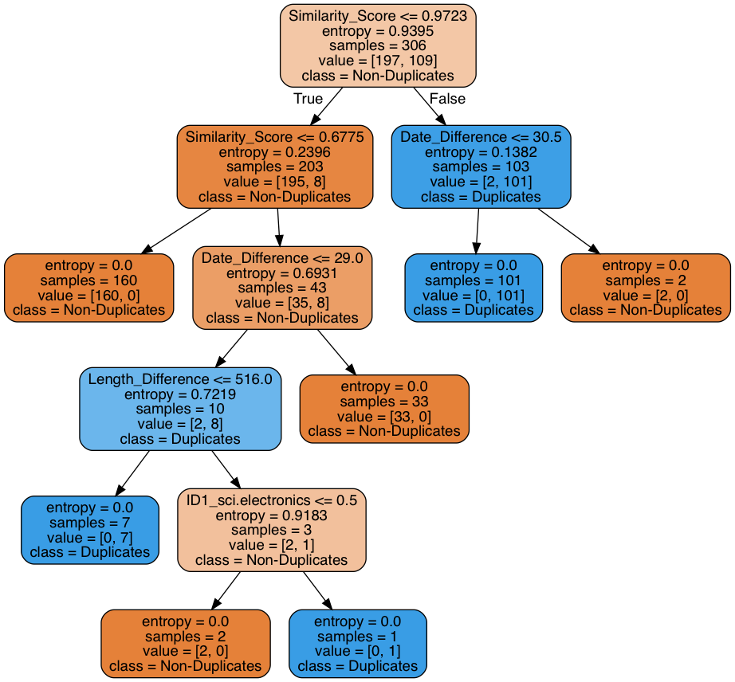

```python
import pydotplus
# Import dot data from classifier
with open("dot_data.pkl", 'rb') as d:
    dot_data = pickle.load(d)

# Graph decision tree from dot data
graph = pydotplus.graph_from_dot_data(dot_data)
Image(graph.create_png())
```

## Predict

```python
# Predict test articles
predicted_response = pd.DataFrame(clf.predict(candidate_duplicates),  index = candidate_duplicates.index).rename(columns = {0:'Predicted_Response'})
```

```python
# Filter predicted duplicates
predicted_duplicates = predicted_response[predicted_response['Predicted_Response']==1]
predicted_duplicates = predicted_duplicates.merge(candidate_duplicates, left_index=True, right_index=True, how = 'inner')
```

```python
print("There are", len(predicted_duplicates), "predicted duplicates")
if len(predicted_duplicates)>0:
    display(predicted_duplicates)
```

```
There are 5 predicted duplicates
```

| ID1 | ID2 | Predicted_Response | Similarity_Score | Length_ID1 | Length_ID2 | Same_Group | Length_Difference | Date_Difference | ID1_alt.atheism | ID1_comp.graphics | ID1_comp.os.ms-windows.misc | ... | ID2_rec.sport.hockey | ID2_sci.crypt | ID2_sci.electronics | ID2_sci.med | ID2_sci.space | ID2_soc.religion.christian | ID2_talk.politics.guns | ID2_talk.politics.mideast | ID2_talk.politics.misc | ID2_talk.religion.misc |
| --- | --- | --- | --- | --- | --- | --- | --- | --- | --- | --- | --- | --- | --- | --- | --- | --- | --- | --- | --- | --- | --- | --- |
| 66999 | 67120 | 1.0 | 0.993592 | 350.0 | 369.0 | 1.0 | 19.0 | 26.0 | 0 | 0 | 0 | ... | 0 | 0 | 0 | 0 | 0 | 0 | 0 | 0 | 0 | 0 |
| 83818 | 83670 | 1.0 | 0.894501 | 1737.0 | 1386.0 | 1.0 | 351.0 | 16.0 | 0 | 0 | 0 | ... | 0 | 0 | 0 | 0 | 0 | 0 | 0 | 0 | 1 | 0 |
| 102988 | 103756 | 1.0 | 0.889589 | 1906.0 | 1749.0 | 1.0 | 157.0 | 5.0 | 0 | 0 | 0 | ... | 0 | 0 | 0 | 0 | 0 | 0 | 0 | 0 | 0 | 0 |
| 102998 | 103003 | 1.0 | 0.910638 | 1367.0 | 1569.0 | 1.0 | 202.0 | 16.0 | 0 | 0 | 0 | ... | 0 | 0 | 0 | 0 | 0 | 0 | 0 | 0 | 0 | 0 |
| 178952 | 178975 | 1.0 | 0.871628 | 594.0 | 976.0 | 1.0 | 382.0 | 5.0 | 0 | 0 | 0 | ... | 0 | 0 | 0 | 0 | 0 | 0 | 0 | 1 | 0 | 0 |

5 rows × 47 columns

Here, from the prediction, we can see that only 5 out of 22 candidate duplicates are actually predicted as duplicates. This is because, the classifier identified `Date_Difference` as an important discriminant. All candidates that have a cosine similarity score > 0.9723 but a difference of 30.5 days or more in filing dates, are predicted as non duplicates but are essentially high similarity non duplicates.

**NOTE:** Please remember that this dataset is a fabricated dataset since we randomly assigned dates to articles. Code and results shown here are better applicable to a real dataset that has its own dates with a possibility of high similarity non duplicates.

You might find that some of the high similarity non duplicates detected in this dataset are not really high similarity non duplicates because this dataset doesn't have such a possibility.

# QUESTIONS?

**Contact Information:**  
Manasa Bulusu  
Data Scientist at S&P Global  
manasa.bulusu@spglobal.com  
LinkedIn: https://linkedin.com/in/manasabulusu